# Лабораторная 2

Дискреционное разграничение прав в Linux. Основные атрибуты

Шалыгин Г. Э.

Российский университет дружбы народов, Москва, Россия

# Информация

## Докладчик

- Шалыгин Георгий Эдуардович
- студент НФИ-02-20
- Российский университет дружбы народов

# Вводная часть

## Актуальность

- - Информационная безопасность - важная часть компетенции в образовательном треке НФИ

## Цели и задачи

- Получение практических навыков работы в консоли с атрибутами файлов, закрепление теоретических основ дискреционного разграничения доступа в современных системах с открытым кодом на базе ОС Linux1.

## Материалы и методы

# Результаты

## Группы доступа

Для нового пользователя guest gid=1001, а uid=1001.

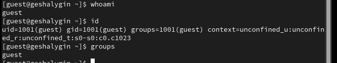

группы доступа

## Изучение прав доступа

Создадим в домашней директории поддиректорию dir1 командой mkdir dir1

В данном случае права доступа по умолчанию 755.

Снимем с директории dir1 все атрибуты командой chmod 000 dir1

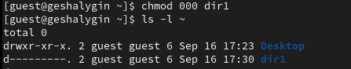

изменение прав

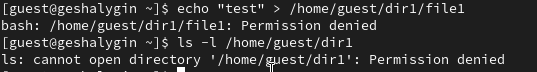

ошибка доступа

## Минимальные права для совершения операций

| Операция | Минимальные права на директорию | Минимальные права на файл |
| --- | --- | --- |
| Создание файла | 300 | 0 |
| Удаление файла | 300 | 0 |
| Чтение файла | 100 | 400 |
| Запись в файл | 100 | 200 |
| Переименование файла | 300 | 0 |
| Создание поддиректории | 300 | 0 |
| Удаление поддиректории | 300 | 0 |

# Вывод

В ходе работы были получены практические навыки работы в консоли с атрибутами файлов, закреплены теоретические основы дискреционного разграничения доступа в современных системах с открытым кодом на базе ОС Linux1.